# Basics of geospatial coordinate reference systems

Author

Jeet Sukumaran

**TipInstall required packages**

You will only need to do this once for each project environment (including your global project environment which is what you typically would start by default when you execute the `julia` command).

```julia
using Pkg
Pkg.add([ "CairoMakie", "DataFrames", "GeoMakie", ])
```

## 1 Background

**Primer**: Geospatial data and coordinate reference systems

## 2 Plotting geospatial data with `GeoAxis`

**Proficiencies**

1. Create a `GeoMakie` geographical figure with given vector data.

**TipRecipes**

Geospatial data visualization recipes

Geospatial data coordinates are encoded using a coordinate reference systems, and we need to use a special type of plotting axis, the `GeoMake.GeoAxis`, to convert these values to Cartesian plotting coordinates.

**TipCoordinate projections**

We say we are *projecting* the coordinates when we do this, and set of coordinates are said to be in one projection or another, depending on their particular coordinate reference systems.

The `GeoMakie.jl.GeoAxis` plotting axis automatically manages geospatial coordinate data projection into Cartesian coordinates. It is used with plotting functions instead of the default Cartesian coordinate system `Axis` when the coordinates in the data need to be projected under a particular geographic coordinate reference system or another for correct visualization or analysis.

```julia
using GeoMakie, CairoMakie
coasts = GeoMakie.coastlines()
fig = Figure()
ax = GeoAxis(fig[1,1])
lines!(ax, coasts)
# save("coastlines.pdf", fig)
# save("coastlines.png", fig)
fig
```

[output not shown]

**1**

Load coastline data into variable `coasts`.

**2**

Create a `Figure` object: a container for the plots.

**3**

Create a `GeoAxis` object: a geospatial CRS-equipped coordinate plotting axis.

**4**

Plot predefined line data on the given plotting axis.

**5**

Save to PDF file.

**6**

Save to PNG file.

**7**

Display in the REPL

## 3 Specifying source and destination projections

**Proficiencies**

1. Create a `GeoMakie` geographical figure with a background of supplied coastline data.
2. Using `PROJ-strings` to specify source and destination projections of the data.

```julia
using GeoMakie, CairoMakie
fig = Figure()
ax = GeoAxis(
  fig[1, 1],
  source = "+proj=longlat +datum=WGS84",
  dest   = "+proj=merc +datum=WGS84"
)
lines!(ax, GeoMakie.coastlines())
fig
```

[output not shown]

## 4 Plotting alternate projections or views

**Proficiencies**

1. Specify alternative map projections using the `dest` keyword argument of `GeoAxis`.
2. Recognize common projection families and their trade-offs (equal-area, conformal, compromise).

The `dest` proj-string controls the *map projection*: the mathematical transformation used to flatten the curved surface of the Earth onto a two-dimensional plane. Every projection makes trade-offs, preserving some spatial properties (area, shape, distance, direction) at the cost of others. The proj-string `+proj=<name>` selects a named projection; additional parameters refine it.

### 4.1 Equirectangular (Plate Carrée) projection

The equirectangular projection maps longitude directly to the x-axis and latitude directly to the y-axis, producing the familiar rectangular grid of the standard wall map. It is the simplest possible projection and serves as a useful baseline. However, it is neither equal-area not conformal, and distortion increases severely toward the poles.

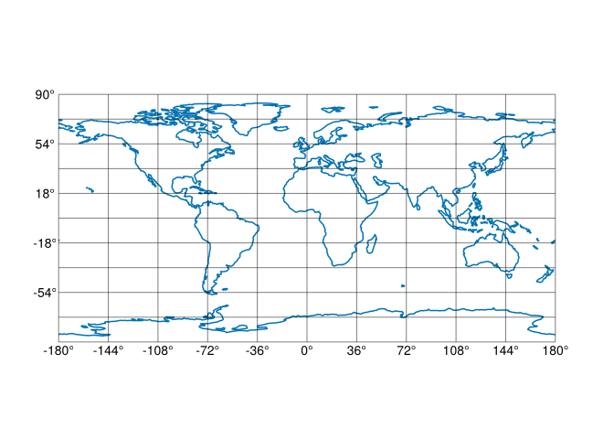

```julia
fig = Figure()
ax = GeoAxis(fig[1, 1]; dest="+proj=longlat")
lines!(ax, GeoMakie.coastlines(ax))
fig
```

### 4.2 Equal Earth projection

The Equal Earth projection is an equal-area pseudocylindrical projection designed to give continents their correct relative sizes while remaining visually appealing.

```julia
fig = Figure()
ax = GeoAxis(fig[1, 1]; dest="+proj=eqearth")
lines!(ax, GeoMakie.coastlines(ax))
fig
```

[output not shown]

### 4.3 Robinson projection

The Robinson projection is a *compromise* projection — it does not perfectly preserve area, shape, or distance, but minimizes overall distortion, giving a visually balanced view of the world. It was used by National Geographic for several decades.

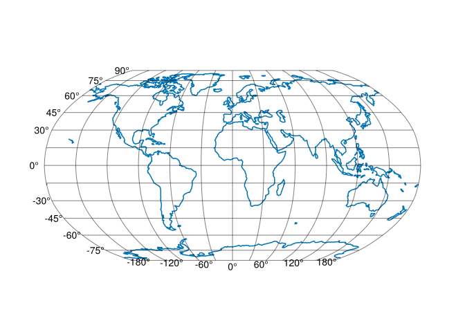

```julia
fig = Figure()
ax = GeoAxis(fig[1, 1]; dest="+proj=robin")
lines!(ax, GeoMakie.coastlines(ax))
fig
```

### 4.4 Mollweide projection

The Mollweide projection is an equal-area elliptical projection. Meridians are elliptical arcs and parallels are horizontal straight lines, with spacing increasing toward the equator to preserve area.

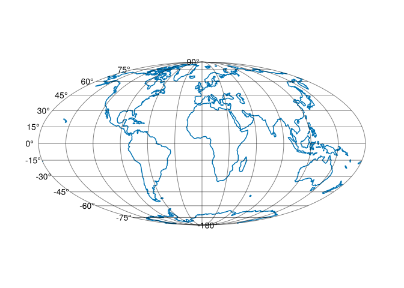

```julia
fig = Figure()
ax = GeoAxis(fig[1, 1]; dest="+proj=moll")
lines!(ax, GeoMakie.coastlines(ax))
fig
```

### 4.5 Orthographic projection

The orthographic projection renders the Earth as it would appear from a distant point in space — a perspective view of a hemisphere. It is neither equal-area nor conformal, but is immediately intuitive.

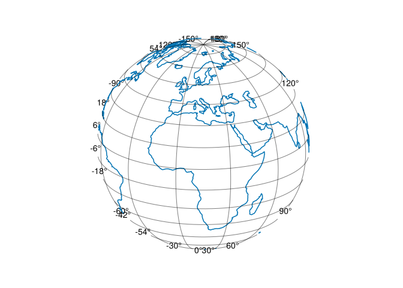

```julia
fig = Figure()
ax = GeoAxis(fig[1, 1]; dest="+proj=ortho +lat_0=20 +lon_0=15")
lines!(ax, GeoMakie.coastlines(ax))
fig
```

The `+lat_0` and `+lon_0` parameters set the latitude and longitude of the center of the visible hemisphere. Regions beyond the horizon are automatically excluded from the plot.

**TipChoosing a projection**

| Projection | Proj-string | Preserves | Common use |
| --- | --- | --- | --- |
| Mercator | `+proj=merc` | Shape (conformal) | Navigation, web maps |
| Equal Earth | `+proj=eqearth` | Area | Thematic maps |
| Robinson | `+proj=robin` | Compromise | General reference |
| Mollweide | `+proj=moll` | Area | Scientific/global data |
| Orthographic | `+proj=ortho` | — | Perspective/visual |
| Lambert Azimuthal | `+proj=laea` | Area | Polar/regional |

No projection preserves all properties simultaneously. For biological data — species ranges, diversity gradients, paleoclimate surfaces — equal-area projections are generally preferred because they ensure that regions of equal true area appear as equal area on the map.

## 5 Plotting alternate centers or framing

**Proficiencies**

1. Re-center a map projection on an arbitrary longitude using the `+lon_0` proj-string parameter.
2. Recognize when re-centering is appropriate for visualizing data in a particular ocean basin or hemisphere.

Every projection has a natural *central meridian*, the longitude that runs vertically through the center of the map. By default this is $0°$ (the prime meridian), which places the Pacific Ocean split between the left and right edges of the map. The `+lon_0` parameter shifts the central meridian to any target longitude, rotating the entire map so that longitude appears in the center. This is useful when your data are concentrated in a region that would otherwise be split across the map edges — Pacific-basin biodiversity studies, for instance, benefit from centering near $180°$ or $-150°$.

### 5.1 Default centering: $0°$, the prime meridian

```julia
fig = Figure()
ax = GeoAxis(fig[1, 1]; dest="+proj=eqearth +lon_0=0")
lines!(ax, GeoMakie.coastlines(ax))
fig
```

[output not shown]

**1**

`+lon_0=0` centers the projection on the prime meridian; this is the default and can be omitted.

### 5.2 Center on $-100°$ (central North America)

```julia
fig = Figure()
ax = GeoAxis(fig[1, 1]; dest="+proj=eqearth +lon_0=-100")
lines!(ax, GeoMakie.coastlines(ax))
fig
```

**1**

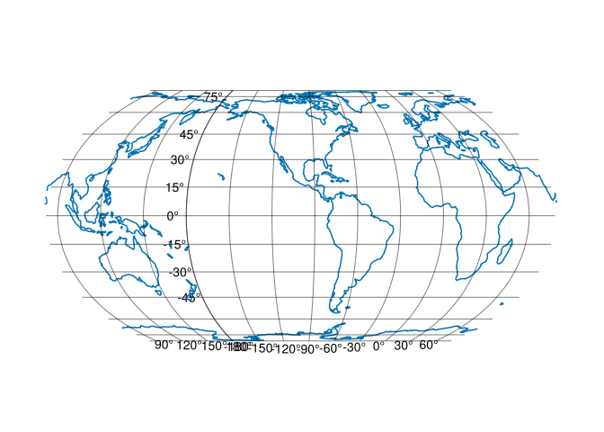

### 5.3 Center on $120°$ (eastern Asia / western Pacific)

```julia
fig = Figure()
ax = GeoAxis(fig[1, 1]; dest="+proj=eqearth +lon_0=120")
lines!(ax, GeoMakie.coastlines(ax))
fig
```

**1**

`+lon_0=120` centers the map on $120°\,\text{E}$, suitable for visualizing data across eastern Asia and the western Pacific.

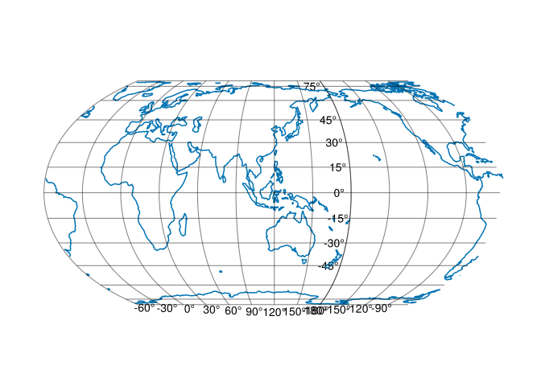

### 5.4 Plotting across the antimeridian

Centering the map on $180°$ (the antimeridian) or plotting data that spans it can produce *rendering artifacts*: line segments whose endpoints straddle the $\pm180°$ boundary are drawn as long near-horizontal lines traversing the full width of the plot, because the renderer naively connects the two endpoints without wrapping.

```julia
fig = Figure()
ax = GeoAxis(fig[1, 1]; dest="+proj=eqearth +lon_0=180")
lines!(ax, GeoMakie.coastlines())
fig
```

**1**

Passing plain `GeoMakie.coastlines()` without the axis argument does not clip or re-segment coastlines to the current projection, so segments that cross the antimeridian produce long horizontal streaks.

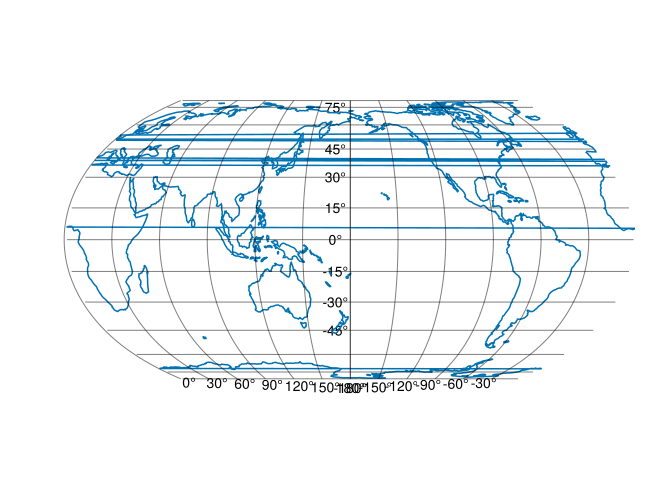

Figure 1

Passing the `GeoAxis` object *into* `GeoMakie.coastlines(ax)` allows GeoMakie to perform axis-aware clipping and re-segmentation of the coastline geometries, resolving most antimeridian artifacts:

```julia
fig = Figure()
ax = GeoAxis(fig[1, 1]; dest="+proj=eqearth +lon_0=180")
lines!(ax, GeoMakie.coastlines(ax))
fig
```

**1**

Supplying the `GeoAxis` to `coastlines` enables axis-aware geometry handling; GeoMakie clips and re-segments features at the projection boundary before rendering, eliminating the crossing artifacts.

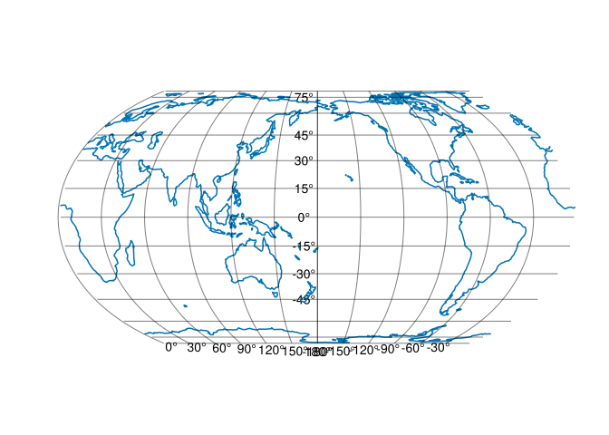

Figure 2

**TipAntimeridian issues with your own data**

Plotting across the antimeridian

## 6 Regional views with plot limits

**Proficiencies**

1. Use the `limits` keyword argument on `GeoAxis` to restrict the rendered region to a geographic bounding box.
2. Identify appropriate longitude and latitude bounds for a region of interest.

The `limits` keyword argument on `GeoAxis` accepts a four-element tuple `(lon_min, lon_max, lat_min, lat_max)` and clips the view to that bounding box.

### 6.1 Southeast Asia

Southeast Asia spans roughly 92°E to 141°E and 11°S to 28°N.

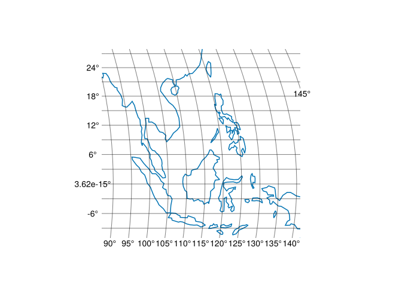

```julia
fig = Figure()
ax = GeoAxis(fig[1, 1];
    limits = (92, 141, -11, 28))
lines!(ax, GeoMakie.coastlines(ax))
fig
```

We can use `dest = "+proj=longlat"` to specify an equirectangular projection.

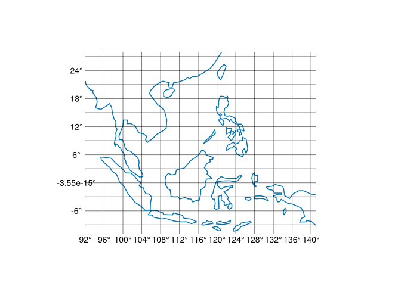

```julia
fig = Figure()
ax = GeoAxis(fig[1, 1];
    dest   = "+proj=longlat",
    limits = (92, 141, -11, 28))
lines!(ax, GeoMakie.coastlines(ax))
fig
```

### 6.2 The Americas

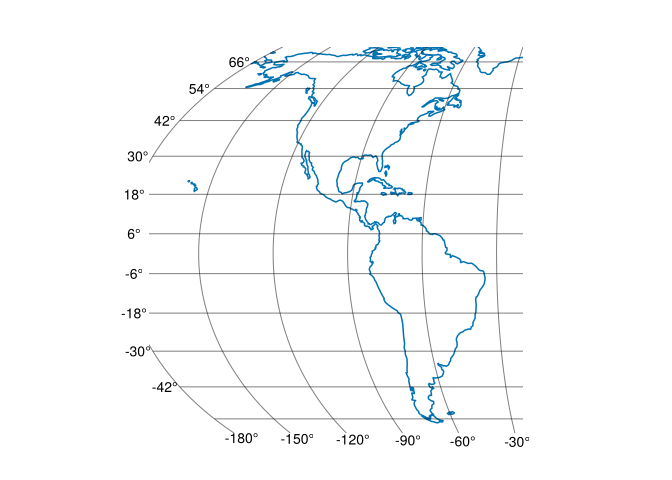

```julia
fig = Figure()
ax = GeoAxis(
    fig[1, 1];
    limits = (-170, -30, -60, 75),
)
lines!(ax, GeoMakie.coastlines(ax))
fig
```

We can use the `dest` keyword to specify a transformation the projection.

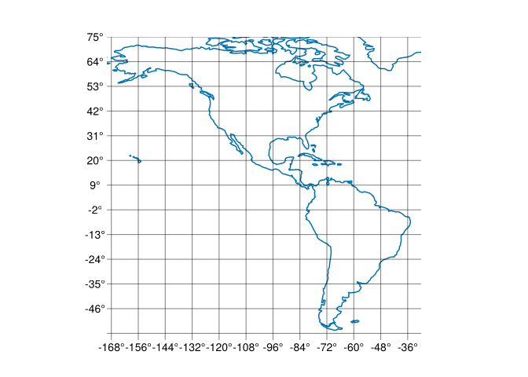

```julia
fig = Figure()
ax = GeoAxis(
    fig[1, 1];
    dest = "+proj=longlat",
    limits = (-170, -30, -60, 75),
)
lines!(ax, GeoMakie.coastlines(ax))
fig
```

### 6.3 Australia

Australia spans roughly 112°E to 155°E and 45°S to 10°S.

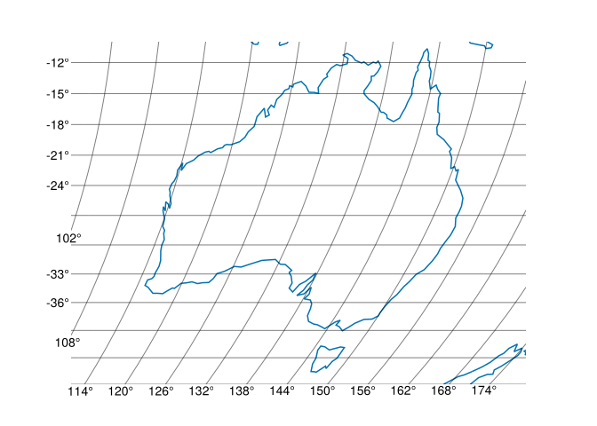

```julia
fig = Figure()
ax = GeoAxis(fig[1, 1];
    limits = (112, 155, -45, -10))
lines!(ax, GeoMakie.coastlines(ax))
fig
```

Or, using `dest = "+proj=longlat"` to specify an equirectangular projection.

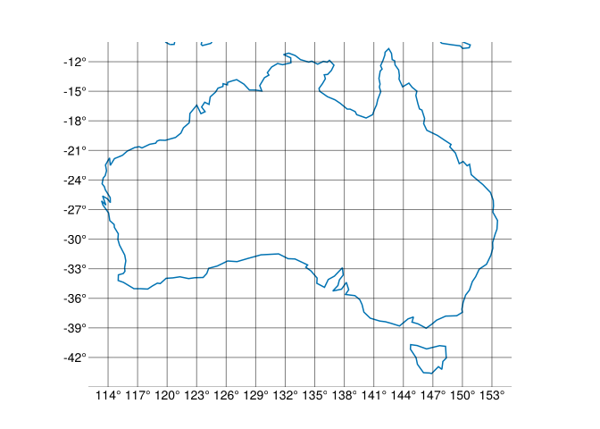

```julia
fig = Figure()
ax = GeoAxis(fig[1, 1];
    dest   = "+proj=longlat",
    limits = (112, 155, -45, -10))
lines!(ax, GeoMakie.coastlines(ax))
fig
```

Back to top